# A3: Incarceration

### Introduction

The United States has the highest incarceration rate globally, disproportionately affecting people of color, especially Black individuals, due to historical and ongoing racism. This assignment focuses on examining how prison and jail populations have changed over time, analyzing the impact of race and gender on these trends using data from the Vera Institute. By using data analysis and visualization skills, I will identify patterns of inequality, and highlight areas needing public attention.

**variebles:**.  
• total_prison_pop: Total prison population.  
• female_prison_pop: Female prison population.  
• male_prison_pop: Male prison population.  
• aapi_prison_pop: Asian American and Pacific Islander prison population.  
• black_prison_pop: Black prison population.  
• latinx_prison_pop: Latinx prison population.  
• native_prison_pop: Native American prison population.  
• other_race_prison_pop: Other race prison population.  
• white_prison_pop: White prison population.

### The Dataset

Who collected the data?

> The data was collected by the Vera Institute of Justice.

How was the data collected or generated?

> The data was collected using multiple sources from the U.S. Department of Justice Bureau of Justice Statistics (BJS) and supplemented with data from state departments of correction when federal data was unavailable. Specific sources include the National Corrections Reporting Program (NCRP), the Deaths in Custody Reporting Program (DCRP), the Annual Survey of Jails (ASJ), and the Census of Jails (COJ).

Why was the data collected?

> The data was collected to provide a comprehensive view of incarceration trends at the county level in the United States, enabling detailed analysis of jail and prison populations, their changes over time, and the impact of race and gender on these trends.

How many observations (rows) are in your data?

> There are 153,811 observations (rows) in the dataset.

How many features (columns) are in the data?

> There are 36 features (columns) in the dataset.

What, if any, ethical questions or questions of power do you need to consider when working with this data?

> Ethical questions to consider include the potential for reinforcing negative stereotypes or stigmatizing communities disproportionately affected by incarceration. It is also important to ensure that data privacy is maintained and that the data is used to promote positive social change rather than punitive measures. Issues of power relate to the systemic biases that have led to disproportionate incarceration rates among people of color, especially Black individuals, and the need to address these biases in any analysis or policy recommendations.

What are possible limitations or problems with this data?

> Potential limitations of the data include gaps or inconsistencies in the data collection process, such as missing data for certain years or counties. Additionally, the data may not fully capture the nuances of individual cases or the broader social and economic factors contributing to incarceration trends. Another limitation is the potential bias in self-reported data or variations in how different jurisdictions record and report their data. Finally, while the dataset provides a comprehensive overview, it may not include qualitative factors that are essential for understanding the human impact of incarceration

### Trends Over Time Chart

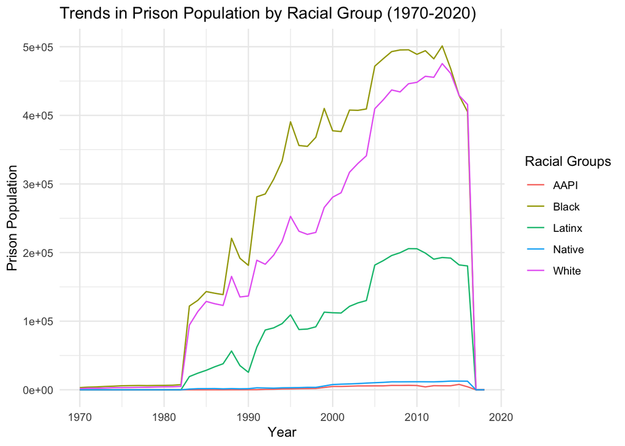

#### Chart Description.

These patterns underscore the disparities in incarceration rates among different racial groups and the overall increase in prison populations over the past five decades.

### Variable Comparison Chart

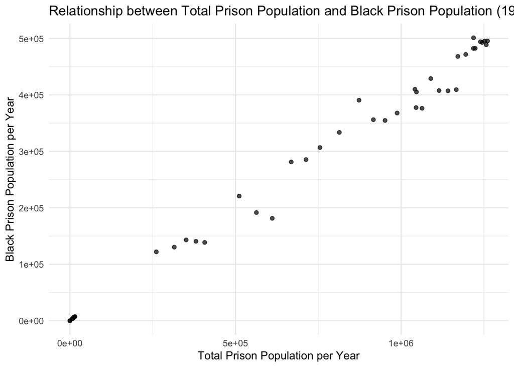

#### Chart Description.

The second chart illustrates the relationship between the total prison population and the Black prison population from 1970 to 2020. This scatter plot was included to explore how changes in the overall prison population correlate with changes in the Black prison population. Two observations can be made from this chart:

- There is a positive correlation between the total prison population and the Black prison population, indicating that as the overall prison population increases, the Black prison population also tends to increase.
- The spread of data points suggests that while the correlation is generally strong, there are periods or specific years where the Black prison population does not increase proportionally to the total prison population, indicating potential policy changes or other influencing factors.

These insights can help in understanding the dynamics of racial disparities in the prison system and guide future research and policy-making efforts to address these issues.

### Map

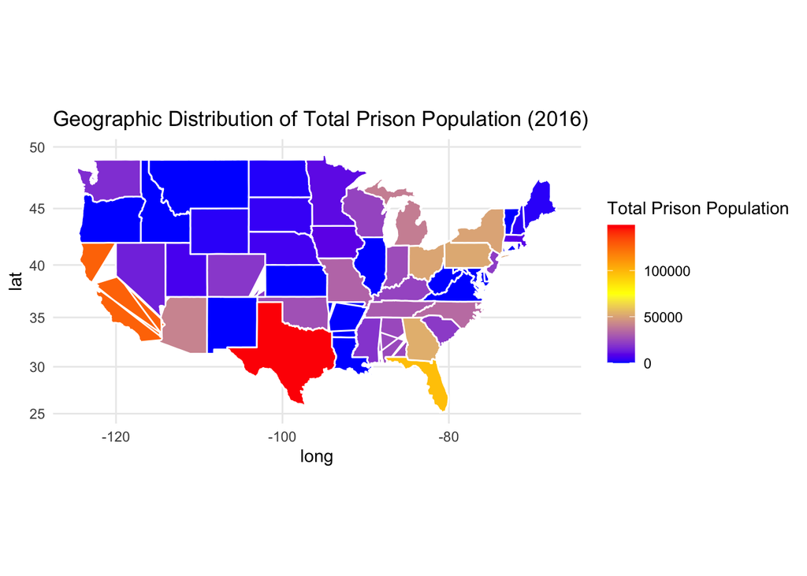

#### Chart Description.

- States with larger populations tend to have higher prison populations, reflecting broader demographic trends.
- There are regional differences in prison populations, which could be influenced by state policies, crime rates, and other socioeconomic factors.

This map helps to highlight the regional disparities in prison populations and can guide policy discussions and resource allocation to address these disparities.